[figure not shown]

# Break Free From Plastic Report

#### Auswertung für Europa

**Zielsetzung**:  
Für den Kontinent Europa wollen wir mit ein paar Häufigkeitstabellen und Visualisierungen mehr über das Projekt [“Break Free From Plastic”](https://www.breakfreefromplastic.org) erfahren. Für den ersten Schritt werden wir uns nur an ein Subset der Daten mit Bezug zu Europa ansehen. Die verwendeten Daten stammen aus einem Datensatz, der im Zuge des [Tidytuesday](https://github.com/rfordatascience/tidytuesday/tree/master/data/2021/2021-01-26) Projektes veröffentlicht wurde.

## 1. Engagement im Projekt

Bei dem Projekt engagieren sich Menschen freiwillig. Wir möchten beginnen uns die Häufigkeiten der Freiwilligen in den einzelnen Ländern näher anzusehen. In welchem Land waren viele Menschen aktiv? Gibt es innerhalb Europas große Unterschiede?

```r
top7_volunteers <- community19_by_country %>%
  # Top 10 filtern
  dplyr::slice_max(
    n = 7,
    order_by = n_volunteers
    ) %>%
  # Spalten auswählen
  dplyr::select(
    country,
    anzahl_freiwillige = n_volunteers
    )
```

### Tabelle

| country | anzahl_freiwillige |
| --- | --- |
| Netherlands | 827 |
| Montenegro | 563 |
| Spain | 330 |
| Switzerland | 327 |
| Italy | 175 |
| Ukraine | 114 |
| Portugal | 43 |

### Grafik

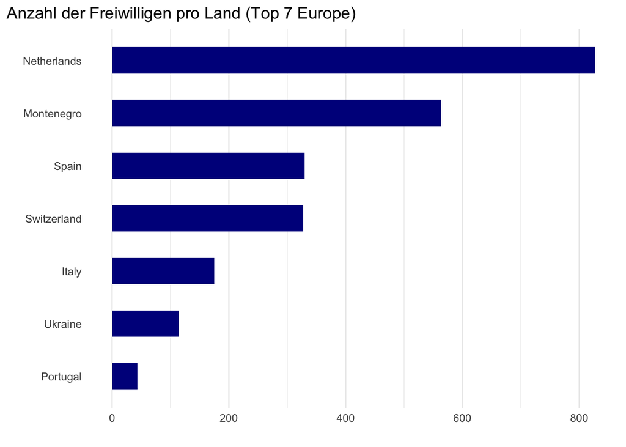

```r
top7_volunteers %>%
  # definiere die Variablen in den aesthetics
  ggplot2::ggplot(
    aes(
      x = anzahl_freiwillige,
      y = fct_reorder(country, anzahl_freiwillige)
      )
    ) +
  # definiere dass die Daten als Balkendiagramm zum Plot hinzugefügt werden sollen
  ggplot2::geom_col(
    width = 0.5, fill = "darkblue"
    ) +
  # definiere die Labels der Abbildung
  ggplot2::labs(
    title = "Anzahl der Freiwilligen pro Land (Top 7 Europe)",
    x = "",
    y = ""
    ) +
  # definiere den Style der Abbildung
  ggplot2::theme_minimal() +
  ggplot2::theme(
    plot.title.position = "plot",
    panel.grid.minor.y = element_blank(),
    panel.grid.major.y = element_blank()
    )
```

–> Das Land mit den **meisten Freiwilligen** ist Netherlands mit insgesamt 827 Freiwilligen in 2019.  
–> Das Land mit den **wenigsten Freiwilligen** ist Portugal mit insgesamt 43Freiwilligen in 2019.

## 2. Events im Projekt

Bei dem Projekt finden Events statt zu denen Meschen zusammenkommen und sich engagieren. Wir möchten uns die Häufigkeiten der Events in den Einzelnen Ländern näher ansehen. In welchem Land fanden viele Events statt? Gibt es innerhalb Europas große Unterschiede?

```r
top7_events <- community19_by_country %>%
  # Top 10 filtern
  dplyr::slice_max(
    n = 7,
    order_by = n_events
    ) %>%
  # Spalten auswählen
  dplyr::select(
    country,
    anzahl_events = n_events
    )
```

### Tabelle

| country | anzahl_events |
| --- | --- |
| Spain | 12 |
| Italy | 9 |
| Ukraine | 7 |
| Switzerland | 6 |
| Germany | 2 |
| Netherlands | 2 |
| Portugal | 2 |

### Grafik

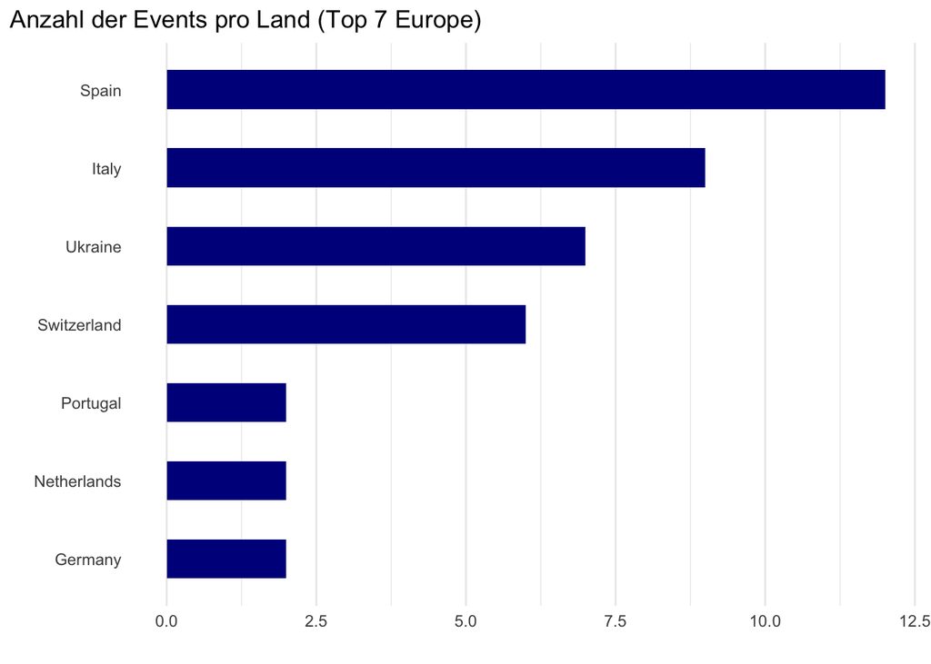

```r
top7_events %>%
  # definiere die Variablen in den aesthetics
  ggplot2::ggplot(
    aes(
      x = anzahl_events,
      y = fct_reorder(country, anzahl_events)
      )
    ) +
  # definiere dass die Daten als Balkendiagramm zum Plot hinzugefügt werden sollen
  ggplot2::geom_col(
    width = 0.5, fill = "darkblue"
    ) +
  # definiere die Labels der Abbildung
  ggplot2::labs(
    title = "Anzahl der Events pro Land (Top 7 Europe)",
    x = "",
    y = ""
    ) +
  # definiere den Style der Abbildung
  ggplot2::theme_minimal() +
  ggplot2::theme(
    plot.title.position = "plot",
    panel.grid.minor.y = element_blank(),
    panel.grid.major.y = element_blank()
    )
```